# Homework Assignment

Christopher Fong

03/12/2020

```r
# Data Input
experiment_data <-  read_sav('data/experiment_data.sav')
survey_data <-  read_sav('data/survey_data.sav')

#Split the survey data based on their characteristics
survey_source <-
  survey_data %>%
  dplyr::select(response_id, contains('source'))

survey_behavior <-
  survey_data %>%
  dplyr::select(response_id, contains('behavior'))

survey_other <-
  survey_data %>%
  dplyr::select(response_id, interst_cbt:interest_coach)

survey_demo <-
  survey_data %>%
  dplyr::select(response_id, d_urban:s_problem, d_marital:weights)

survey_philosophy <-
  survey_data %>%
  dplyr::select(response_id, contains('m1_philosophy'))
```

### 1. Data checking, missing and deuplicated data

```r
#Check is there any missing data or any duplicated data

#Duplication check
duplicate_survey_data<-survey_data%>%
  group_by(response_id)%>%
  summarise(count = n())%>%
  filter(count > 1)

print(nrow(duplicate_survey_data))
```

```
## [1] 0
```

There is no duplicated data in the survey data

```r
#Check if there is any Duplicated data for experiment data

duplicate_experiment_data<-experiment_data%>%
  group_by(response_id, duration,offer, outcome, price, rtb, social_proof)%>%
  dplyr::summarise(count = n())%>%
  filter(count > 1)

print(nrow(duplicate_experiment_data))
```

```
## [1] 20
```

As there are duplicared data in the experiment dataset, the next step is to check whether they are consitent or not.

```r
# Merge the dataset for consitent checking
duplicate_experiment_data2<-duplicate_experiment_data%>%
  ungroup()%>%
  mutate(case = row_number())%>%
  left_join(experiment_data, c('response_id', 'duration','offer', 'outcome', 'price', 'rtb', 'social_proof'))

#Figure out cases that with contradict answer given same combination
contradict_case = duplicate_experiment_data2%>%
  dplyr::select(case, answer)%>%
  unique()%>%
  group_by(case)%>%
  summarise(count = n())%>%
  filter(count > 1)

print(paste0("There are ",nrow(contradict_case), " occasions that there is contradiction between choices of the respondent, same questions but different answer"))
```

```
## [1] "There are 3 occasions that there is contradiction between choices of the respondent, same questions but different answer"
```

Because their answer is inconsistnet, the respondent are not rational in this research. I would remove them from the analysis.

```r
#Select those ID which have contradict answer as they are not reliable
id_to_remove = duplicate_experiment_data2%>%
  filter(case %in% contradict_case$case)%>%
  dplyr::select(response_id)%>%
  unique()

#Remove duplicated case and contradict respondent
experiment_data_dedup_decon = experiment_data%>%
  filter(! response_id %in% id_to_remove$response_id)%>%
  dplyr::select(-task)%>%
  unique()
```

### 2. Descriptive Data analysis

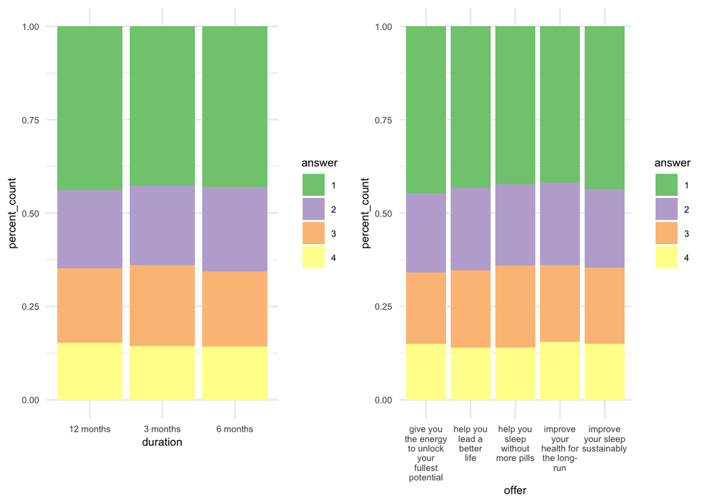

```r
#Distribution plot for all the attributes in experiment data

distribution_plot = function(data, ...){
  ans_dist<- data%>%
    group_by(..., answer)%>%
    dplyr::summarise(count = n())%>%
    group_by(...)%>%
    mutate(percent_count = count / sum(count))%>%
    dplyr::select(-count)%>%
    mutate(answer = as.factor(answer))

  ggplot(ans_dist, aes(x = ..., y = percent_count, fill = answer))+
    geom_bar(stat = "identity")+
    scale_fill_brewer(palette="Accent")+
    theme_minimal()+
    theme(text = element_text(size =8))
}

experiment_data_dedup_decon_plot<-experiment_data_dedup_decon%>%
  mutate(offer        = str_wrap(offer, 10),
         outcome      = str_wrap(outcome, 10),
         rtb          = str_wrap(rtb, 10),
         social_proof = str_wrap(social_proof, 10))

ans_dist_plot_1 <- distribution_plot(experiment_data_dedup_decon_plot, duration)
ans_dist_plot_2 <- distribution_plot(experiment_data_dedup_decon_plot, offer)
ans_dist_plot_3 <- distribution_plot(experiment_data_dedup_decon_plot, outcome)
ans_dist_plot_4 <- distribution_plot(experiment_data_dedup_decon_plot, rtb)
ans_dist_plot_5 <- distribution_plot(experiment_data_dedup_decon_plot, social_proof)
ans_dist_plot_6 <- distribution_plot(experiment_data_dedup_decon_plot, price)


egg::ggarrange(ans_dist_plot_1, ans_dist_plot_2, ncol = 2)
```

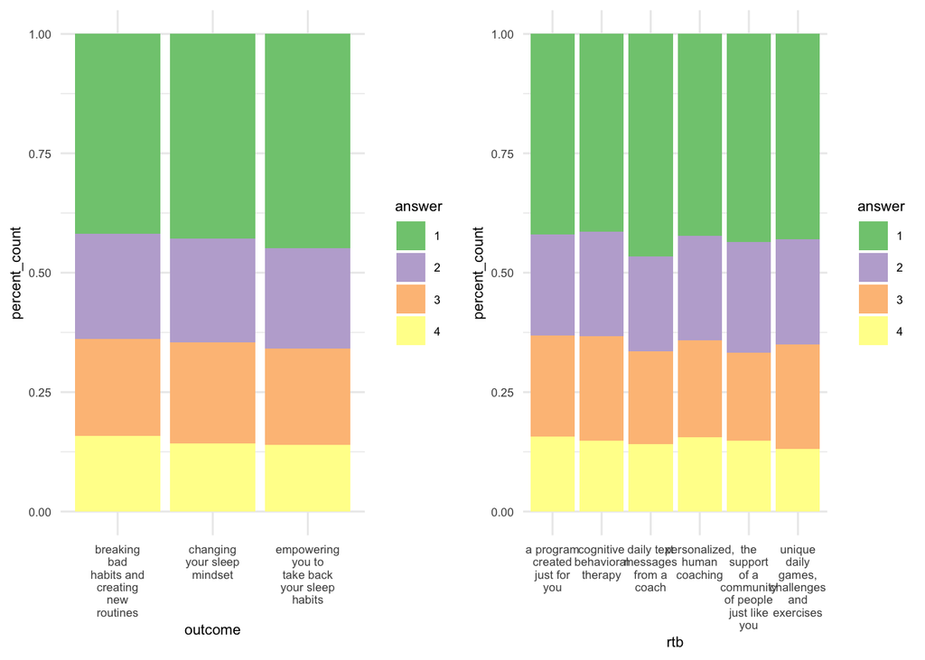

```r
egg::ggarrange(ans_dist_plot_3, ans_dist_plot_4, ncol = 2)
```

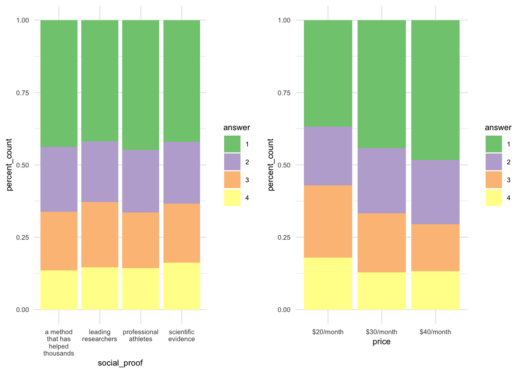

```r
egg::ggarrange(ans_dist_plot_5, ans_dist_plot_6, ncol = 2)
```

Based on above distribution plot, the distribution of the answer for duration and offer don’t have much variation For outcome, “breaking bad habits and creating new rountines” have more very likely and somewhat likely to download For rtb, wiht pharses “daily text messages from a coach” is less likely to download For social proof, “Scientific evidence” and “leading researchers” are preferred over the other 2 While for price, $20/month is much more attractive than the other 2 plans

There aren’t much changes in ordering when we combing 3&4 and 1&2 except for duration. So I would keep it at 4 levels at the initial stage

### 3. Modelling the data

### 3a. Initial conjoint model with lm

Conjoint with the ordiary sacle is used to analyise the relative impact of each variables

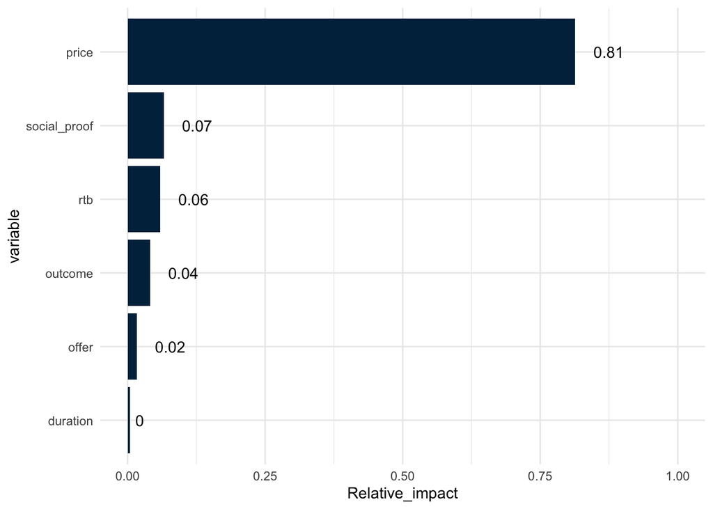

```r
#Convert all the variables to factor
experiment_data_dedup_decon[,2:7] <- lapply(experiment_data_dedup_decon[,2:7], factor)

#Built the first model using conjoint
model_cj<-lm(answer ~ duration+offer+outcome+price+rtb+social_proof,
           data = experiment_data_dedup_decon)

#Calculate relative Impact of the model
relImp <- calc.relimp(model_cj, type =c("lmg"), rela = TRUE)

#Plot the result
relative_impact<-relImp@lmg%>%data.frame()
colnames(relative_impact)<-"Relative_impact"

relative_impact$variable<-rownames(relative_impact)
relative_impact$label <- round(relative_impact$Relative_impact, 2) #create label for plotting

relative_impact<-relative_impact%>%
  arrange(Relative_impact)%>%
   mutate(variable=factor(variable, levels=variable)) #Ordering the plot by relative impact

ggplot(relative_impact, aes(x = variable, y = Relative_impact))+
  geom_bar(stat = "identity", fill = "#002B49")+
  theme_minimal()+
  geom_text(aes(label = label, hjust = -0.6), color = "black")+
  ylim(0,1)+
  coord_flip()
```

Based on the above result, Price is the dominant factor on the descision to download the application or not

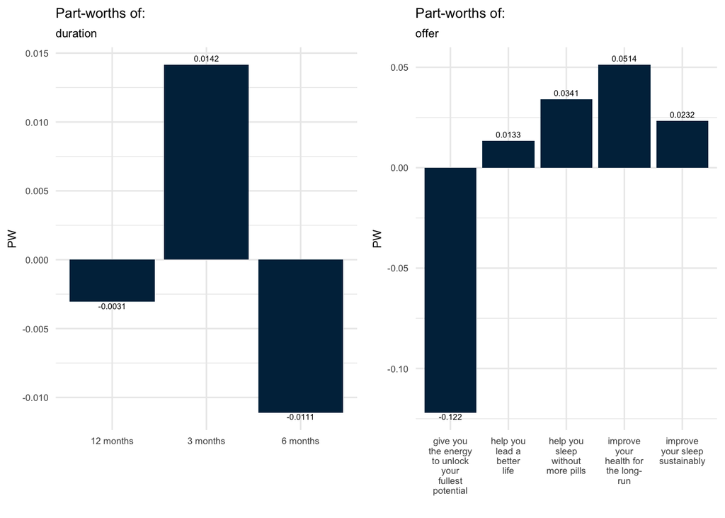

```r
#Individual part-wroths plot

#Get the coefficient of the model
coef = model_cj$coefficients%>%
  data.frame()

#Create variables to merge with dataset to be create to get attribute and level
coef$to_merge<-rownames(coef)

#Get all attributes and levels
pw_df<-NULL

for (i in 1:6){
  tmp<-experiment_data_dedup_decon[i+1]%>%
    unique()%>%
    data.frame()%>%
    mutate(Attributes = colnames(experiment_data_dedup_decon[i+1]))

  colnames(tmp)[1] = "Levels"

  pw_df<-pw_df%>%
    bind_rows(tmp)
}

#Combine both dataset
pw_df<-pw_df%>%
  mutate(to_merge = paste0(Attributes, Levels))%>%
  left_join(coef, 'to_merge')%>%
  rename("PW" = ".")

#Calculate the PW for the remaining level which don't have coefficient (based on the conjoint package, it is - of the sum of all the other levels)
pw_df_remaining = pw_df%>%
  group_by(Attributes)%>%
  summarise(PW_remaining = -sum(PW, na.rm = T))

#Combine with the pw_df to the the full PW dataset
pw_df_full<-pw_df%>%
  left_join(pw_df_remaining, 'Attributes')%>%
  mutate(PW = ifelse(is.na(PW) == T, PW_remaining, PW))%>%
  dplyr::select(-PW_remaining)



#Loop over the attributes to create the plot

for (i in 1: length(unique(pw_df_full$Attributes))){
  To_plot = pw_df_full%>%
    filter(Attributes == unique(pw_df_full$Attributes)[i])%>%
    mutate(Levels = str_wrap(Levels, 10))%>%
    mutate(vjust = ifelse(PW <0, 1.2, -0.6))

  p1<-ggplot(To_plot, aes(x = Levels, y = PW))+
    geom_bar(stat = "identity", fill = "#002B49")+
    theme_minimal()+
    geom_text(aes(label = round(PW, 4), vjust = vjust), color = "black", size = 2)+
    ggtitle(paste0("Part-worths of:"), unique(pw_df_full$Attributes)[i])+
    xlab("")+
    theme(text = element_text(size =8))

  assign(paste0('plot_', i), p1)

}


egg::ggarrange(plot_1, plot_2, ncol = 2)
```

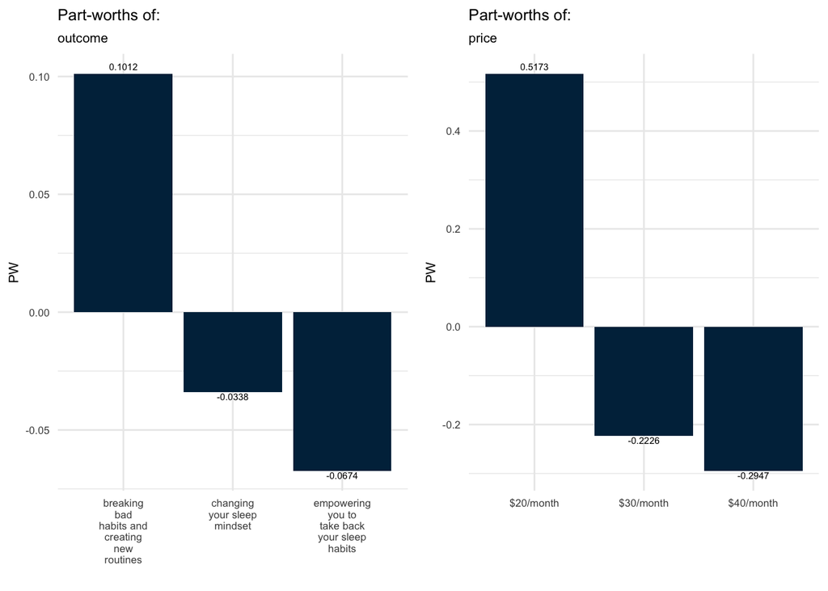

```r
egg::ggarrange(plot_3, plot_4, ncol = 2)
```

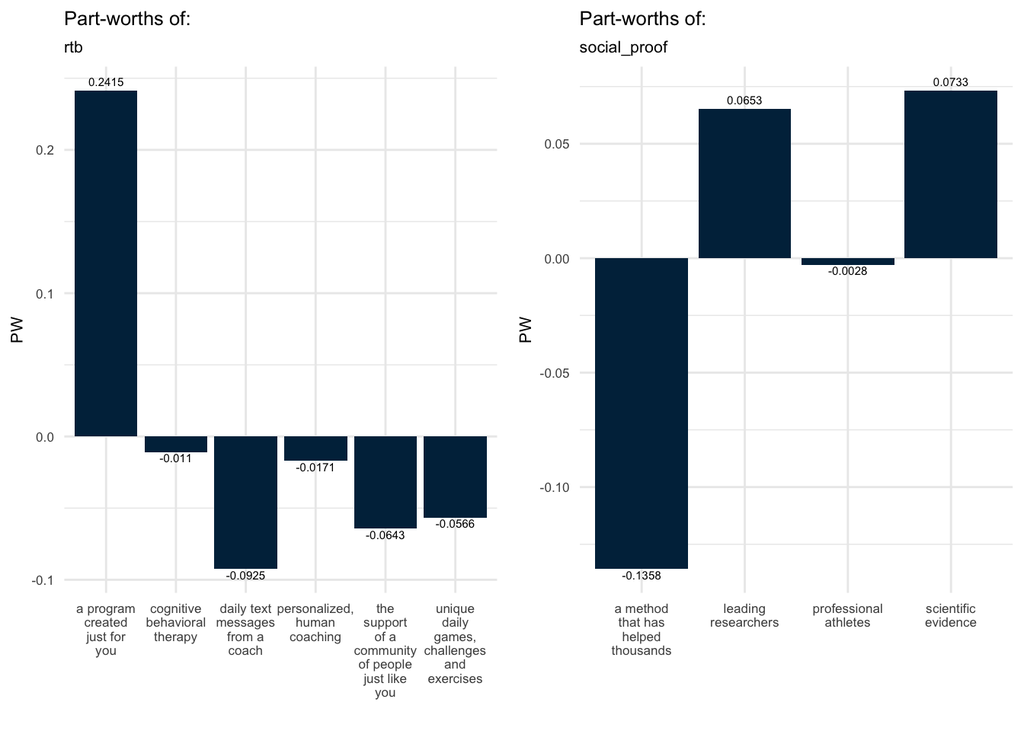

```r
egg::ggarrange(plot_5, plot_6, ncol = 2)
```

For each attributes, the followings have most positive impact to the likelihood to download the application: Duration: 3 months offer is relatively more attractive to the other 2. It is worth to investigate why 6 months is less attractive to 12 months. One of the possible reason is that if people are interested in the application, they would prefer to have a longer relationship

Offer: People who are likely to download care about the helath for the long-run far more than being energize. In other words, they are more consider the long term impact than the short term

Outcome: The result of outcome consistent with the result from offer. People care about health and long term benefit.

Price: Lower subscrition is highly preffered over the higher one

rtb: People prefer targeted progroamme over generic items.

social proof: Respondents believe in science and research over experience without scientific backup

### 3b. Initial conjoint model with lm by price level

Based on above results price is the dominat factor affecting whether perople to download the application or not. How would price interact with other variables or would there be any different under different price levels.

The next step is to see if there are any changes on relative impact under different price

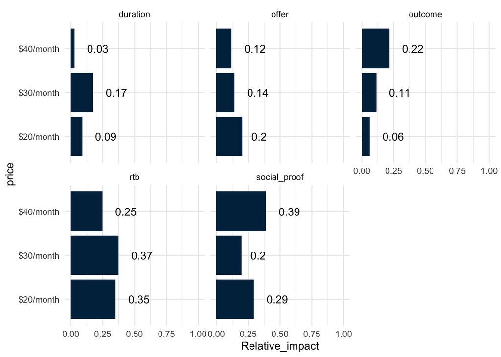

```r
#Split data into different price level
experiment_data_dedup_decon_20 = experiment_data_dedup_decon%>%filter(price == "$20/month")
experiment_data_dedup_decon_30 = experiment_data_dedup_decon%>%filter(price == "$30/month")
experiment_data_dedup_decon_40 = experiment_data_dedup_decon%>%filter(price == "$40/month")

#Built 3 models of different price level  using conjoint
model_cj_20<-lm(answer ~ duration+offer+outcome+rtb+social_proof,
           data = experiment_data_dedup_decon_20)

model_cj_30<-lm(answer ~ duration+offer+outcome+rtb+social_proof,
           data = experiment_data_dedup_decon_30)

model_cj_40<-lm(answer ~ duration+offer+outcome+rtb+social_proof,
           data = experiment_data_dedup_decon_40)

#Calculate relative Impact of the model
relImp_20 <- calc.relimp(model_cj_20, type =c("lmg"), rela = TRUE)
relImp_30 <- calc.relimp(model_cj_30, type =c("lmg"), rela = TRUE)
relImp_40 <- calc.relimp(model_cj_40, type =c("lmg"), rela = TRUE)


relative_impact_20<-relImp_20@lmg%>%data.frame()
relative_impact_30<-relImp_30@lmg%>%data.frame()
relative_impact_40<-relImp_40@lmg%>%data.frame()

relative_impact_20$variable<-rownames(relative_impact_20)
relative_impact_30$variable<-rownames(relative_impact_30)
relative_impact_40$variable<-rownames(relative_impact_40)

relative_impact_20 <- relative_impact_20%>%mutate(price = "$20/month")
relative_impact_30 <- relative_impact_30%>%mutate(price = "$30/month")
relative_impact_40 <- relative_impact_40%>%mutate(price = "$40/month")


relative_impact_price <- relative_impact_20%>%
  bind_rows(relative_impact_30)%>%
  bind_rows(relative_impact_40)


colnames(relative_impact_price)[1]<-"Relative_impact"


relative_impact_price$label <- round(relative_impact_price$Relative_impact, 2) #create label for plotting

ggplot(relative_impact_price, aes(x = price, y = Relative_impact))+
  geom_bar(stat = "identity", fill = "#002B49")+
  facet_wrap(~variable)+
  theme_minimal()+
  geom_text(aes(label = label, hjust = -0.6), color = "black")+
  ylim(0,1)+
  coord_flip()
```

rtb and social_proof are the most influential attributes in all price level but at $40/month, social proof is more influential than others It is also remarkable that duration is the third influential attributes at $30/month which is much lower in other price level

### 4. Clustering on groups of respondent

### 4a. Segmentation on the indivdual fitted model

To indentify whether there are any particular groups of respondent which share similar chareteristic, we first build an conjoint model for each individual. The coefficient in the model would show how each individual likelihood to downloand would change aganist varaibles.

We first build the cluster based on those data

```r
indv_coef<-NULL

#Build the  model for each indvidual and get the utility for all the variables
for (i in 1: length(unique(experiment_data_dedup_decon$response_id))){

  #Get the individual data
  indv_df = experiment_data_dedup_decon%>%
    filter(response_id == unique(experiment_data_dedup_decon$response_id)[i])

 #Build the model
  model_indv<-lm(answer ~ duration+offer+outcome+price+rtb+social_proof+0,
                 data = indv_df)

  #Get the coefficient
  coef_indv = model_indv$coefficients%>%
    data.frame()

  #MCombine dataset
  coef_indv$to_merge<-rownames(coef_indv)
  coef_indv$id = unique(experiment_data_dedup_decon$response_id)[i]

  coef_indv<-coef_indv%>%
    rename("PW" = ".")

  indv_coef<-indv_coef%>%
    rbind(coef_indv)
}

# Convert table to wide format
indv_PW<-indv_coef%>%
  spread(to_merge, PW)

#Assume all the NA are 0
indv_PW[is.na(indv_PW)] <- 0
```

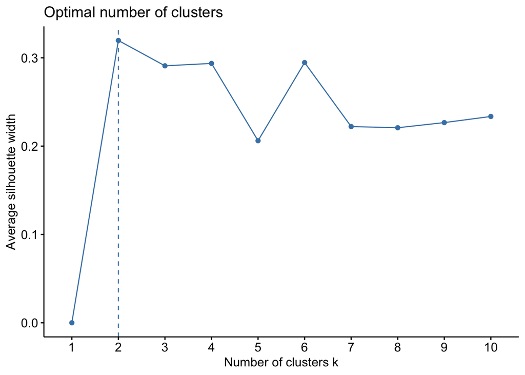

```r
# Using kmeans and determine the optimal number of k by various method

#silhouette
fviz_nbclust(indv_PW[,2:20], kmeans, method = "silhouette")
```

```r
#Gap Stat
gap_stat <- clusGap(indv_PW[,2:20], FUN = kmeans, nstart = 25,
                    K.max = 10, B = 50)
```

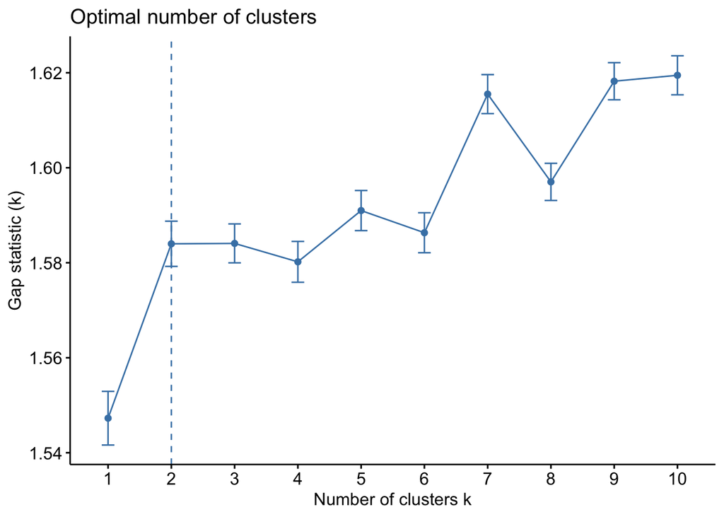

```r
fviz_gap_stat(gap_stat)
```

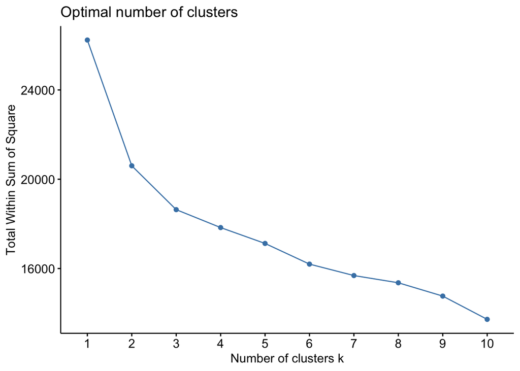

```r
#Elbow
fviz_nbclust(indv_PW[,2:20], kmeans, method = "wss")
```

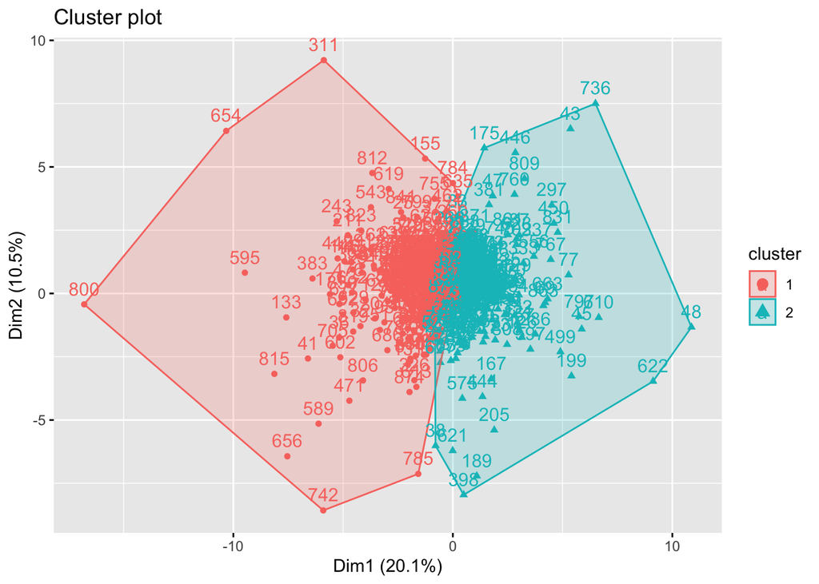

```r
k_clust_indv_PW = indv_PW[,2:20]

k2 <- kmeans(k_clust_indv_PW, centers = 2, nstart = 25)
k3 <- kmeans(k_clust_indv_PW, centers = 3, nstart = 25)
k6 <- kmeans(k_clust_indv_PW, centers = 6, nstart = 25)

fviz_cluster(k2, data = k_clust_indv_PW)
```

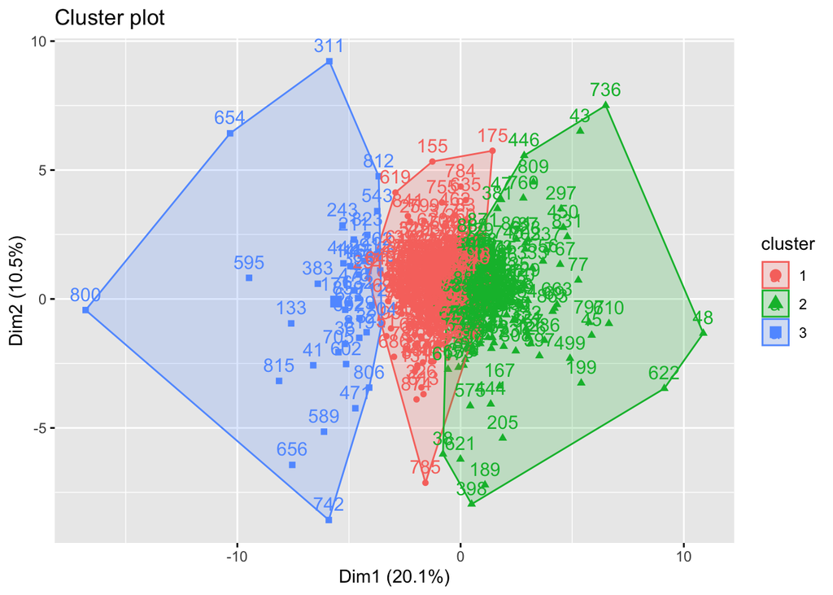

```r
fviz_cluster(k3, data = k_clust_indv_PW)
```

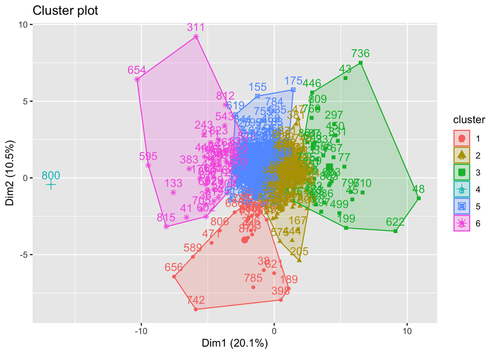

```r
fviz_cluster(k6, data = k_clust_indv_PW)
```

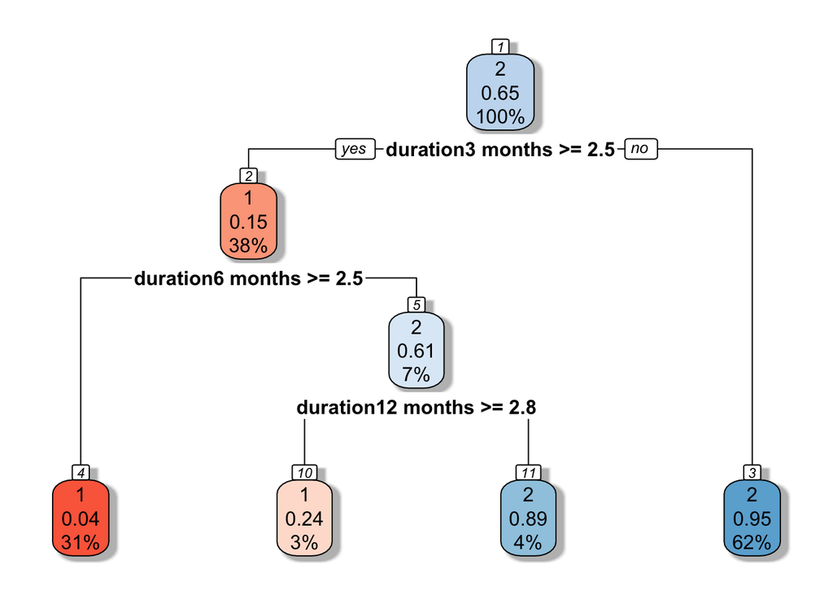

```r
#Explain each individual group by tree diagram

tree_data_k2<-k_clust_indv_PW %>% mutate(cluster = factor(k2$cluster))
tree_data_k3<-k_clust_indv_PW %>% mutate(cluster = factor(k3$cluster))
tree_data_k6<-k_clust_indv_PW %>% mutate(cluster = factor(k6$cluster))

tree_k2 <- rpart::rpart(cluster~., data=tree_data_k2, cp=.02)
tree_k3 <- rpart::rpart(cluster~., data=tree_data_k3, cp=.02)
tree_k6 <- rpart::rpart(cluster~., data=tree_data_k6, cp=.02)

rpart.plot(tree_k2, box.palette="RdBu", shadow.col="gray", nn=TRUE)
```

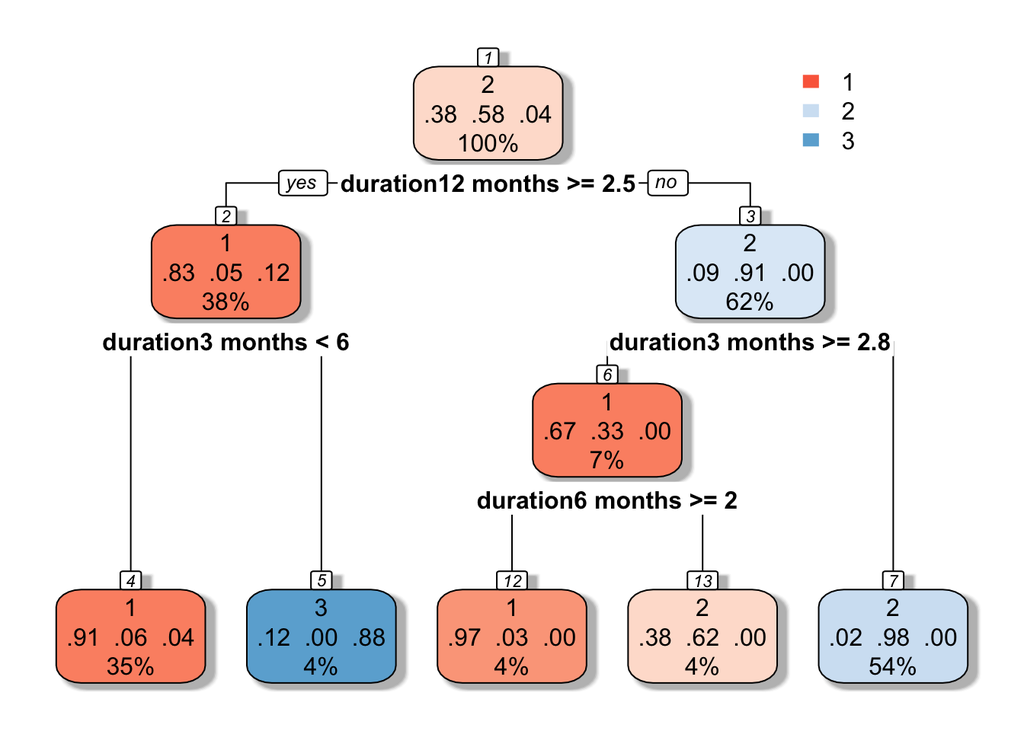

```r
rpart.plot(tree_k3, box.palette="RdBu", shadow.col="gray", nn=TRUE)
```

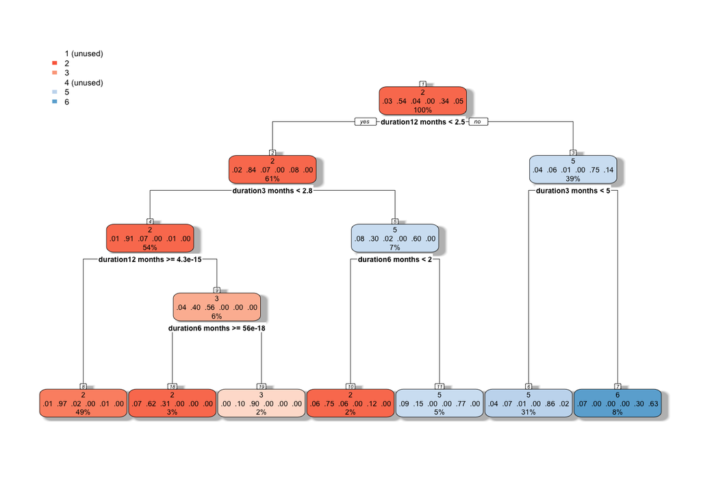

```r
rpart.plot(tree_k6, box.palette="RdBu", shadow.col="gray", nn=TRUE)
```

Based on above tree diagram, there are larger difference between how the respondents react to likely to download under different duration. Take 2 groups case as an examples, group 1 are more reactive to duration, while group 2 are less reactive to duration

When 2 center points compared:

```r
library(DT)
options(scipen=999)
datatable(round(t(k2$centers), 3), options = list(
  searching = FALSE))
```

|  | 1 | 2 |
| --- | --- | --- |
| duration12 months | 4.07 | 1.289 |
| duration3 months | 4.048 | 1.257 |
| duration6 months | 3.975 | 1.268 |
| offerhelp you lead a better life | -0.547 | 0.219 |
| offerhelp you sleep without more pills | -0.731 | 0.233 |
| offerimprove your health for the long-run | -0.755 | 0.342 |
| offerimprove your sleep sustainably | -0.643 | 0.239 |
| outcomechanging your sleep mindset | -0.232 | 0.196 |
| outcomeempowering you to take back your sleep habits | -0.353 | 0.11 |
| price$30/month | -0.516 | 0.022 |

[output cut: 9 more lines]

```r
# kable(k2$centers, caption = "center point of cluster with k = 2")
```

Group 1’s average PW are much larger than group 2 meaning they are more sensitve person

```r
cluster = cbind(indv_PW$id, k2$cluster, k3$cluster, k6$cluster)%>%data.frame()
colnames(cluster) = c('response_id', 'k2_cluster', 'k3_cluster', 'k6_cluster')

experiment_data_dedup_decon_cluster<-experiment_data_dedup_decon%>%
  left_join(cluster, 'response_id')

experiment_data_dedup_decon_cluster%>%
  dplyr::group_by(k2_cluster)%>%
  summarise(answer = mean(answer))
```

```
## # A tibble: 2 x 2
##   k2_cluster answer
##   <chr>       <dbl>
## 1 1            2.80
## 2 2            1.67
```

```r
experiment_data_dedup_decon_cluster%>%
  dplyr::group_by(k3_cluster)%>%
  summarise(answer = mean(answer))
```

```
## # A tibble: 3 x 2
##   k3_cluster answer
##   <chr>       <dbl>
## 1 1            2.75
## 2 2            1.57
## 3 3            2.74
```

```r
experiment_data_dedup_decon_cluster%>%
  dplyr::group_by(k6_cluster)%>%
  summarise(answer = mean(answer))
```

```
## # A tibble: 6 x 2
##   k6_cluster answer
##   <chr>       <dbl>
## 1 1            2.48
## 2 2            1.51
## 3 3            2.25
## 4 4            2.33
## 5 5            2.79
## 6 6            2.79
```